# MUSA508-HW4-Housing Subsidy Algorithm

Yiming Ma

10/29/2020

```r
palette5 <- c( "#ff4500",'#e3eec2'  , '#853353' ,'#2f8fb1', '#f4ac94')

palette2 <- c("#1f95ac","#ffb026")

subsidy <- read.csv("C:/Users/Yiming Ma/Documents/UPenn/MUSA508/hw/hw4/housingSubsidy.csv")

# View(subsidy)
# y.numeric = 1: take the program
# y.numeric = 0: not take the programs

# colnames(subsidy)
# table(subsidy$education)
# table(subsidy$y)

# 451/4119
```

## I. Introduction and Motivation

The home repair tax credit program can be seen as an incentive for homeowners to renovate the house and increase the home value. The Department of Housing and Community Development (HCD) tries to reach out to eligible homeowners every year, but in a random manner, the uptake of the credit is only 11%. Thus, a more targeted campaign is needed.

## II. Exploratory Analysis

### 1. Develop and interpret data visualizations that describe feature importance/correlation.

As shown in Figure 2.1, only 451 homeowners (10.95%) of the total 4,119 homeowners reached out to take the credit.

The behavior of taking the credit was not significantly affected by lien against the owner’s property (`taxLien`), homeowners’ age (`age`).

*Note: Feasures `age` and `pdays` are regarded as continuous variables here for better virualization though they labeled a categorical variables in the codebook provided.*

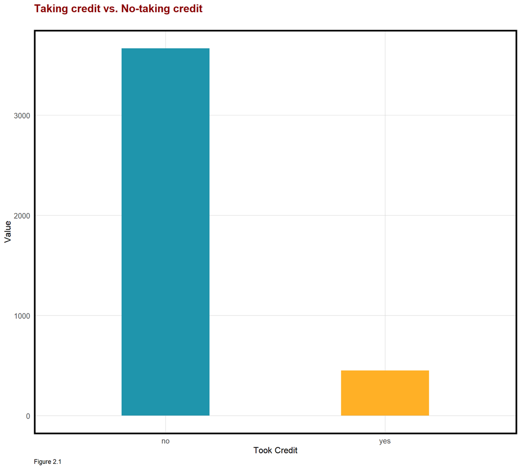

```r
ggplot(data = subsidy) +
  geom_bar(aes(y,fill = y),width = 0.4) +
          scale_fill_manual(values = palette2,
                          name = 'Took Credit') +
  labs(x="Took Credit", y="Value",
           title = "Taking credit vs. No-taking credit\n",
       caption = 'Figure 2.1') +
      theme(legend.position = "none") +
  plotTheme()
```

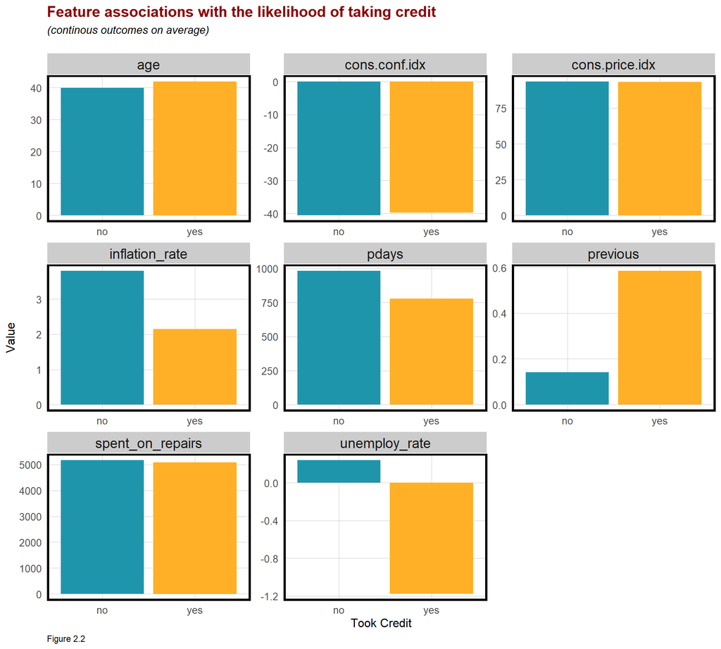

```r
subsidy %>%
  dplyr::select(y,previous, unemploy_rate,cons.price.idx,cons.conf.idx,inflation_rate, spent_on_repairs, age, pdays) %>%
  gather(Variable, value, -y) %>%
    ggplot(aes(y, value, fill=y)) +
      geom_bar(position = "dodge", stat = "summary", fun.y = "mean") +
      facet_wrap(~Variable, ncol = 3, scales = "free") +
        scale_fill_manual(values = palette2,
                          name = 'Took Credit') +
      labs(x="Took Credit", y="Value",
           title = "Feature associations with the likelihood of taking credit",
           subtitle = "(continous outcomes on average)\n",
       caption = 'Figure 2.2') +
      theme(legend.position = "none") +
  plotTheme()
```

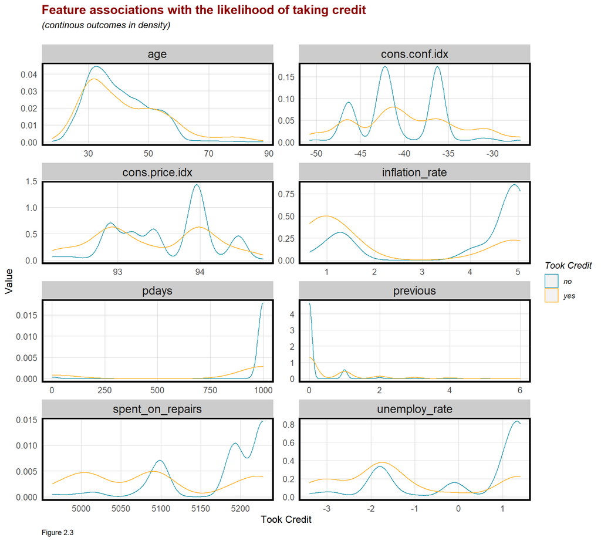

```r
subsidy %>%
  dplyr::select(y,previous, unemploy_rate,cons.price.idx,cons.conf.idx,inflation_rate, spent_on_repairs, age, pdays) %>%
    gather(Variable, value, -y) %>%
    ggplot() +
    geom_density(aes(value, color=y), fill = "transparent") +
    facet_wrap(~Variable, ncol = 2, scales = "free") +
        scale_color_manual(values = palette2,
                          name = 'Took Credit') +
    labs(x="Took Credit", y="Value",
           title = "Feature associations with the likelihood of taking credit",
           subtitle = "(continous outcomes in density)\n",
       caption = 'Figure 2.3') +
      theme(legend.position = "right") +
  plotTheme()
```

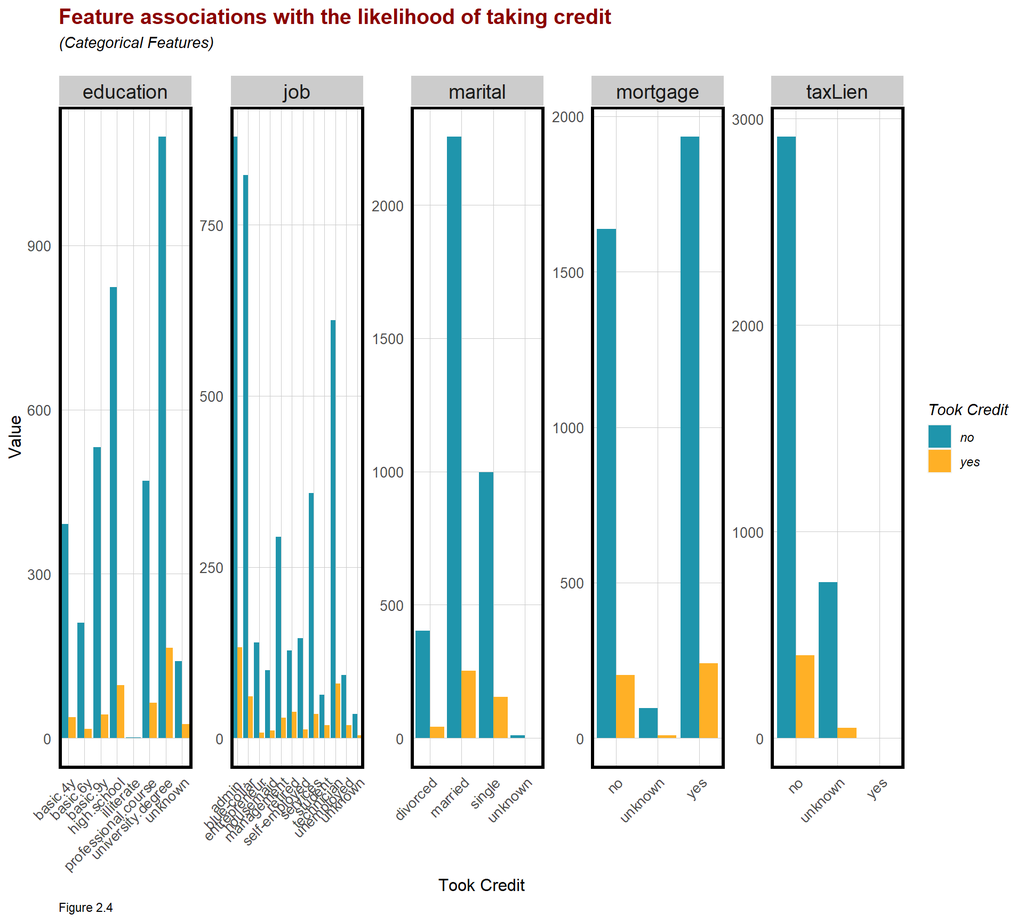

```r
subsidy %>%
    dplyr::select(y,job, marital,education,taxLien,mortgage) %>%
    gather(Variable, value, -y) %>%
    count(Variable, value, y) %>%
      ggplot(., aes(value, n, fill = y)) +
        geom_bar(position = "dodge", stat="identity") +
        facet_wrap(~Variable, ncol = 5, scales="free") +
        scale_fill_manual(values = palette2,
                          name = 'Took Credit') +
        labs(x="Took Credit", y="Value",
             title = "Feature associations with the likelihood of taking credit",
             subtitle = "(Categorical Features)\n",
       caption = 'Figure 2.4') +
        theme(axis.text.x = element_text(angle = 45, hjust = 1)) +
  plotTheme()
```

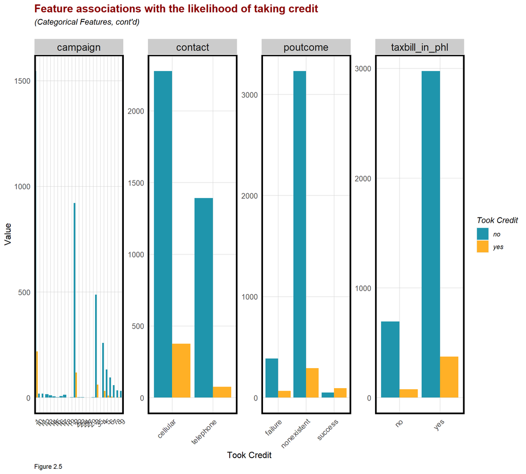

```r
subsidy %>%
    dplyr::select(y,taxbill_in_phl,contact, campaign,poutcome) %>%
    gather(Variable, value, -y) %>%
    count(Variable, value, y) %>%
      ggplot(., aes(value, n, fill = y)) +
        geom_bar(position = "dodge", stat="identity") +
        facet_wrap(~Variable, ncol = 4, scales="free") +
        scale_fill_manual(values = palette2,
                          name = "Took Credit") +
        labs(x="Took Credit", y="Value",
             title = "Feature associations with the likelihood of taking credit",
             subtitle = "(Categorical Features, cont'd)\n",
       caption = 'Figure 2.5') +
        theme(axis.text.x = element_text(angle = 45, hjust = 1)) +
  plotTheme()
```

## III. Initial Model Building

In this section, this project tries to build a **Logistic Regression** model with all existing features.

### 3.1 Split dataset into a 65/35 training/test set

### 3.2 Build a model with all features

The first model was built with all features in the dataset included. Only few features (`contacttelephone`, `monthdec`, `campaign`, etc.)are significantly related to whether an individual took the credit or not, indicting that the model needs to be refined.

```r
subsidyreg1 <- glm(y_numeric ~ .,
                  data=subsidyTrain %>% dplyr::select(-X,
                                                    -y,-taxLien),
                  family="binomial" (link="logit"))

summary(subsidyreg1)
```

```
##
## Call:
## glm(formula = y_numeric ~ ., family = binomial(link = "logit"),
##     data = subsidyTrain %>% dplyr::select(-X, -y, -taxLien))
##
## Deviance Residuals:
##     Min       1Q   Median       3Q      Max
## -2.4312  -0.4130  -0.3410  -0.2743   2.7971
##
## Coefficients:
##                                 Estimate  Std. Error z value Pr(>|z|)
## (Intercept)                  -64.4569819 131.5866187  -0.490   0.6242
## age                            0.0040401   0.0085015   0.475   0.6346
## jobblue-collar                -0.2019782   0.2695338  -0.749   0.4536
## jobentrepreneur               -0.4398813   0.4574926  -0.962   0.3363
## jobhousemaid                  -0.6081370   0.5533354  -1.099   0.2718
## jobmanagement                 -0.2958843   0.3058101  -0.968   0.3333
## jobretired                    -0.0770689   0.3703018  -0.208   0.8351
## jobself-employed              -0.7201679   0.4588905  -1.569   0.1166
## jobservices                   -0.3785310   0.2992370  -1.265   0.2059
## jobstudent                    -0.5827998   0.4749019  -1.227   0.2197
## jobtechnician                 -0.0815229   0.2332106  -0.350   0.7267
## jobunemployed                 -0.0036131   0.4282215  -0.008   0.9933
## jobunknown                    -0.3449106   0.6996710  -0.493   0.6220
## maritalmarried                 0.0025538   0.2390554   0.011   0.9915
## maritalsingle                 -0.0272334   0.2743888  -0.099   0.9209
## maritalunknown               -11.7954967 329.2148401  -0.036   0.9714
## educationbasic.6y              0.3670326   0.3999401   0.918   0.3588
## educationbasic.9y             -0.0754439   0.3385100  -0.223   0.8236
## educationhigh.school           0.1334629   0.3225799   0.414   0.6791
## educationilliterate          -13.1856118 882.7435574  -0.015   0.9881
## educationprofessional.course   0.1791336   0.3502604   0.511   0.6091
## educationuniversity.degree     0.2875891   0.3230265   0.890   0.3733
## educationunknown               0.3203488   0.4125826   0.776   0.4375
## mortgageunknown               -0.1105733   0.5672672  -0.195   0.8455
## mortgageyes                   -0.2088628   0.1428249  -1.462   0.1436
## taxbill_in_phlyes              0.1817119   0.2008873   0.905   0.3657
## contacttelephone              -0.6417183   0.2850122  -2.252   0.0244 *
## monthaug                       0.0119168   0.4435987   0.027   0.9786
## monthdec                       1.8188174   0.7795533   2.333   0.0196 *
```

[output cut: 16 more lines]

```
## unemploy_rate                 -0.9391549   0.4866028  -1.930   0.0536 .
## cons.price.idx                 0.9077695   0.8614268   1.054   0.2920
## cons.conf.idx                  0.0229236   0.0292698   0.783   0.4335
## inflation_rate                 0.4997422   0.4479791   1.116   0.2646
## spent_on_repairs              -0.0044715   0.0107313  -0.417   0.6769
## ---
## Signif. codes:  0 '***' 0.001 '**' 0.01 '*' 0.05 '.' 0.1 ' ' 1
##
## (Dispersion parameter for binomial family taken to be 1)
##
##     Null deviance: 1853.7  on 2678  degrees of freedom
## Residual deviance: 1489.0  on 2629  degrees of freedom
## AIC: 1589
##
## Number of Fisher Scoring iterations: 13
```

### 3.3 Make Prediction and Plot Outcomes

A dataframe of predictions for the 1440 observations in the test set was created, called `testProbs`.

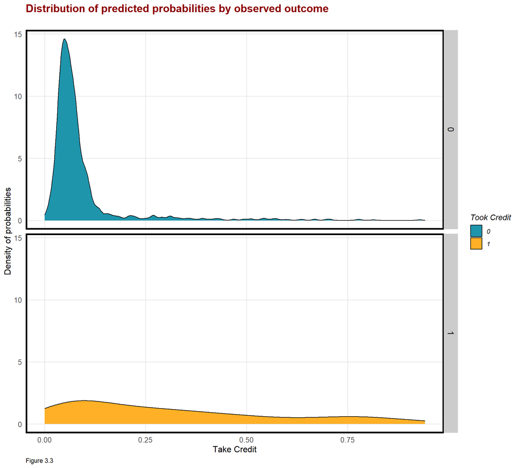

```r
# subsidyreg1$xlevels$taxLien <- union(subsidyreg1$xlevels$taxLien,
# levels(as.factor(subsidyTest$taxLien)))
testProbs1 <- data.frame(Outcome1 = as.factor(subsidyTest$y_numeric),
                        Probs1 = predict(subsidyreg1, newdata = subsidyTest, na.rm = TRUE, type= "response" ))

# glimpse(testProbs1)

ggplot(testProbs1, aes(x = Probs1, fill = as.factor(Outcome1))) +
  geom_density() +
  facet_grid(Outcome1 ~ .) +
  scale_fill_manual(values = palette2,
                    name = "Took Credit") +
  labs(x = "Take Credit", y = "Density of probabilities",
       title = "Distribution of predicted probabilities by observed outcome\n",
       caption = 'Figure 3.3') +
  theme(strip.text.x = element_text(size = 18),
        legend.position = "right") +
  plotTheme()
```

### 3.4 Good of Fit: Confusion Matrix

A “confusion matrix” for the threshold of 50% shows us the rate at which we got True Positives (aka Sensitivity), False Positives, True Negatives (aka Specificity) and False Negatives for that threshold.

- True Positives: Predicted correctly homeowner would take the credit.
- False Positives: Predicted incorrectly homeowner would take the credit.
- True Negatives: Predicted correctly homeowner would not take the credit.
- False Negatives: We predicted that a homeowner would not take the credit but they did.

It is obvious that this initial model is suffering low sensitivity (0.24), indicating we need to re-build the model or optimizing it.

```r
testProbs1 <-
  testProbs1 %>%
  mutate(predOutcome1  = as.factor(ifelse(testProbs1$Probs1 > 0.5 , 1, 0)))

caret::confusionMatrix(testProbs1$predOutcome1, testProbs1$Outcome1,
                       positive = "1")
```

```
## Confusion Matrix and Statistics
##
##           Reference
## Prediction    0    1
##          0 1258  119
##          1   25   38
##
##                Accuracy : 0.9
##                  95% CI : (0.8833, 0.915)
##     No Information Rate : 0.891
##     P-Value [Acc > NIR] : 0.1449
##
##                   Kappa : 0.3019
##
##  Mcnemar's Test P-Value : 0.000000000000009189
##
##             Sensitivity : 0.24204
##             Specificity : 0.98051
##          Pos Pred Value : 0.60317
##          Neg Pred Value : 0.91358
##              Prevalence : 0.10903
##          Detection Rate : 0.02639
##    Detection Prevalence : 0.04375
##       Balanced Accuracy : 0.61128
##
##        'Positive' Class : 1
##
```

## IV. Model Optimization

### 4.1 Feature Engineering

```r
subsidy$edu.level[subsidy$education == "basic.4y" |subsidy$education == "basic.6y"|subsidy$education == "basic.9y"] <- "Basic"
subsidy$edu.level[subsidy$education == "unknown" |subsidy$education == "illiterate"] <- "Others"
subsidy$edu.level[subsidy$education == "high.school"]  <- "High School"
subsidy$edu.level[subsidy$education == "professional.course"]  <- "Professional"
subsidy$edu.level[subsidy$education == "university.degree"]  <- "University"

subsidy <- subsidy %>%
  dplyr::mutate(precontact = ifelse(previous == "0","no","yes"),
                contactInterval = ifelse(pdays > 7,"Long","Short") )
```

### 4.2 Model Building

```r
set.seed(3456)
trainIndex <- createDataPartition(subsidy$y, p = .65,
                                  list = FALSE,
                                  times = 1)
subsidyTrain <- subsidy[ trainIndex,]
subsidyTest  <- subsidy[-trainIndex,]

subsidyreg2 <- glm(y_numeric ~ .,
                  data=subsidyTrain %>%
                    dplyr::select(-X,-y,-age,-education,-taxLien,-pdays,-previous,-month,-job),
                  family="binomial" (link="logit"))


stargazer(subsidyreg1, type = "html",
          title = "Table 4.2.1 Summary Statistics of Model 1 on Training Set",
          header = FALSE,
          single.row = TRUE)
```

**Table 4.2.1 Summary Statistics of Model 1 on Training Set**

|  | *Dependent variable:* |
| --- | --- |
|  | y_numeric |
| age | 0.004 (0.009) |
| jobblue-collar | -0.202 (0.270) |
| jobentrepreneur | -0.440 (0.457) |
| jobhousemaid | -0.608 (0.553) |
| jobmanagement | -0.296 (0.306) |
| jobretired | -0.077 (0.370) |
| jobself-employed | -0.720 (0.459) |
| jobservices | -0.379 (0.299) |
| jobstudent | -0.583 (0.475) |
| jobtechnician | -0.082 (0.233) |
| jobunemployed | -0.004 (0.428) |
| jobunknown | -0.345 (0.700) |
| maritalmarried | 0.003 (0.239) |
| maritalsingle | -0.027 (0.274) |
| maritalunknown | -11.795 (329.215) |
| educationbasic.6y | 0.367 (0.400) |
| educationbasic.9y | -0.075 (0.339) |
| educationhigh.school | 0.133 (0.323) |
| educationilliterate | -13.186 (882.744) |
| educationprofessional.course | 0.179 (0.350) |
| educationuniversity.degree | 0.288 (0.323) |
| educationunknown | 0.320 (0.413) |
| mortgageunknown | -0.111 (0.567) |
| mortgageyes | -0.209 (0.143) |
| taxbill_in_phlyes | 0.182 (0.201) |
| contacttelephone | -0.642** (0.285) |
| monthaug | 0.012 (0.444) |
| monthdec | 1.819** (0.780) |
| monthjul | 0.099 (0.374) |
| monthjun | 0.060 (0.472) |
| monthmar | 1.391** (0.569) |
| monthmay | -0.410 (0.316) |
| monthnov | -0.615 (0.425) |
| monthoct | 0.070 (0.548) |
| monthsep | -0.926 (0.683) |
| day_of_weekmon | -0.317 (0.221) |
| day_of_weekthu | -0.141 (0.215) |
| day_of_weektue | -0.157 (0.217) |
| day_of_weekwed | -0.205 (0.231) |
| campaign | -0.108** (0.043) |
| pdays | -0.001 (0.001) |
| previous | 0.243 (0.213) |
| poutcomenonexistent | 0.743** (0.350) |
| poutcomesuccess | 1.110 (0.748) |
| unemploy_rate | -0.939* (0.487) |
| cons.price.idx | 0.908 (0.861) |
| cons.conf.idx | 0.023 (0.029) |
| inflation_rate | 0.500 (0.448) |
| spent_on_repairs | -0.004 (0.011) |
| Constant | -64.457 (131.587) |
| Observations | 2,679 |
| Log Likelihood | -744.481 |
| Akaike Inf. Crit. | 1,588.962 |
| *Note:* | p<0.1; p<0.05; p<0.01 |

```r
stargazer(subsidyreg2, type = "html",
          title = "Table 4.2.2 Summary Statistics of Model 2 on Training Set",
          header = FALSE,
          single.row = TRUE)
```

**Table 4.2.2 Summary Statistics of Model 2 on Training Set**

|  | *Dependent variable:* |
| --- | --- |
|  | y_numeric |
| maritalmarried | -0.018 (0.230) |
| maritalsingle | -0.061 (0.245) |
| maritalunknown | -11.947 (329.038) |
| mortgageunknown | -0.023 (0.526) |
| mortgageyes | -0.169 (0.139) |
| taxbill_in_phlyes | 0.156 (0.195) |
| contacttelephone | -0.900*** (0.216) |
| day_of_weekmon | -0.253 (0.215) |
| day_of_weekthu | -0.151 (0.211) |
| day_of_weektue | -0.162 (0.212) |
| day_of_weekwed | -0.237 (0.225) |
| campaign | -0.100** (0.043) |
| poutcomenonexistent | 0.383* (0.212) |
| poutcomesuccess | 1.483*** (0.573) |
| unemploy_rate | -0.891*** (0.225) |
| cons.price.idx | 1.465*** (0.357) |
| cons.conf.idx | 0.065*** (0.021) |
| inflation_rate | -0.004 (0.286) |
| spent_on_repairs | 0.004 (0.005) |
| edu.levelHigh School | 0.129 (0.205) |
| edu.levelOthers | 0.348 (0.330) |
| edu.levelProfessional | 0.244 (0.231) |
| edu.levelUniversity | 0.369** (0.187) |
| precontactyes |  |
| contactIntervalShort | 0.337 (0.588) |
| Constant | -156.582*** (54.618) |
| Observations | 2,679 |
| Log Likelihood | -769.184 |
| Akaike Inf. Crit. | 1,588.367 |
| *Note:* | p<0.1; p<0.05; p<0.01 |

### 4.3 Make Prediction and Plot Outcomes

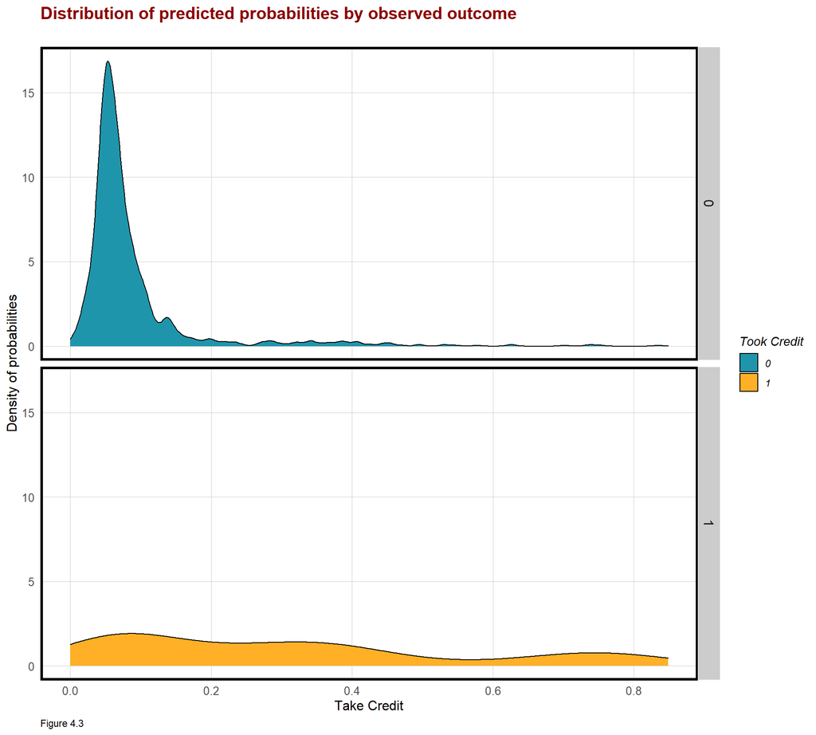

```r
testProbs2 <- data.frame(Outcome2 = as.factor(subsidyTest$y_numeric),
                        Probs2 = predict(subsidyreg2, newdata = subsidyTest, na.rm = TRUE, type= "response" ))



ggplot(testProbs2, aes(x = Probs2, fill = as.factor(Outcome2))) +
  geom_density() +
  facet_grid(Outcome2 ~ .) +
  scale_fill_manual(values = palette2,
                          name = "Took Credit") +
  labs(x = "Take Credit", y = "Density of probabilities",
       title = "Distribution of predicted probabilities by observed outcome\n",
       caption = 'Figure 4.3') +
  theme(strip.text.x = element_text(size = 18),
        legend.position = "right") +
  plotTheme()
```

### 4.4 Good of Fit: Confusion Matrix

Unfortunately, the steps in data engineering did not improve the sensitivity of the model. The sensitivity dropped from 0.24 to 0.21.

```r
testProbs2 <-
  testProbs2 %>%
  mutate(predOutcome2  = as.factor(ifelse(testProbs2$Probs2 > 0.5 , 1, 0)))

caret::confusionMatrix(testProbs2$predOutcome2, testProbs2$Outcome2,
                       positive = "1")
```

```
## Confusion Matrix and Statistics
##
##           Reference
## Prediction    0    1
##          0 1272  124
##          1   11   33
##
##                Accuracy : 0.9062
##                  95% CI : (0.89, 0.9208)
##     No Information Rate : 0.891
##     P-Value [Acc > NIR] : 0.0325
##
##                   Kappa : 0.2947
##
##  Mcnemar's Test P-Value : <0.0000000000000002
##
##             Sensitivity : 0.21019
##             Specificity : 0.99143
##          Pos Pred Value : 0.75000
##          Neg Pred Value : 0.91117
##              Prevalence : 0.10903
##          Detection Rate : 0.02292
##    Detection Prevalence : 0.03056
##       Balanced Accuracy : 0.60081
##
##        'Positive' Class : 1
##
```

### 4.5 Cross Validation on Both Models

The same result is shown in Figure 4.1 and 4.2, With sensitivity decreased slightly after adjusting features.

```r
ctrl <- trainControl(method = "cv", number = 100, classProbs=TRUE, summaryFunction=twoClassSummary)


cvFit.reg1 <- train(y ~ ., data = subsidy %>%
                  dplyr::select(-y_numeric, -X) %>%
                  dplyr::mutate(y = ifelse(y=="no","c1.yes","c1.no")),
                method="glm", family="binomial",
                metric="ROC", trControl = ctrl)

cvFit.reg2 <- train(y ~ ., data = subsidy %>%
                  dplyr::select(-X,-y_numeric,-age,-education,-taxLien,-pdays,-previous) %>%
                  dplyr::mutate(y = ifelse(y=="no","c2.yes","c2.no")),
                method="glm", family="binomial",
                metric="ROC", trControl = ctrl)


cvFit.reg1
```

```
## Generalized Linear Model
##
## 4119 samples
##   22 predictor
##    2 classes: 'c1.no', 'c1.yes'
##
## No pre-processing
## Resampling: Cross-Validated (100 fold)
## Summary of sample sizes: 4077, 4077, 4078, 4078, 4078, 4077, ...
## Resampling results:
##
##   ROC        Sens    Spec
##   0.7691055  0.2195  0.9809009
```

```r
cvFit.reg2
```

```
## Generalized Linear Model
##
## 4119 samples
##   17 predictor
##    2 classes: 'c2.no', 'c2.yes'
##
## No pre-processing
## Resampling: Cross-Validated (100 fold)
## Summary of sample sizes: 4078, 4078, 4077, 4077, 4078, 4077, ...
## Resampling results:
##
##   ROC        Sens    Spec
##   0.7658097  0.2175  0.982545
```

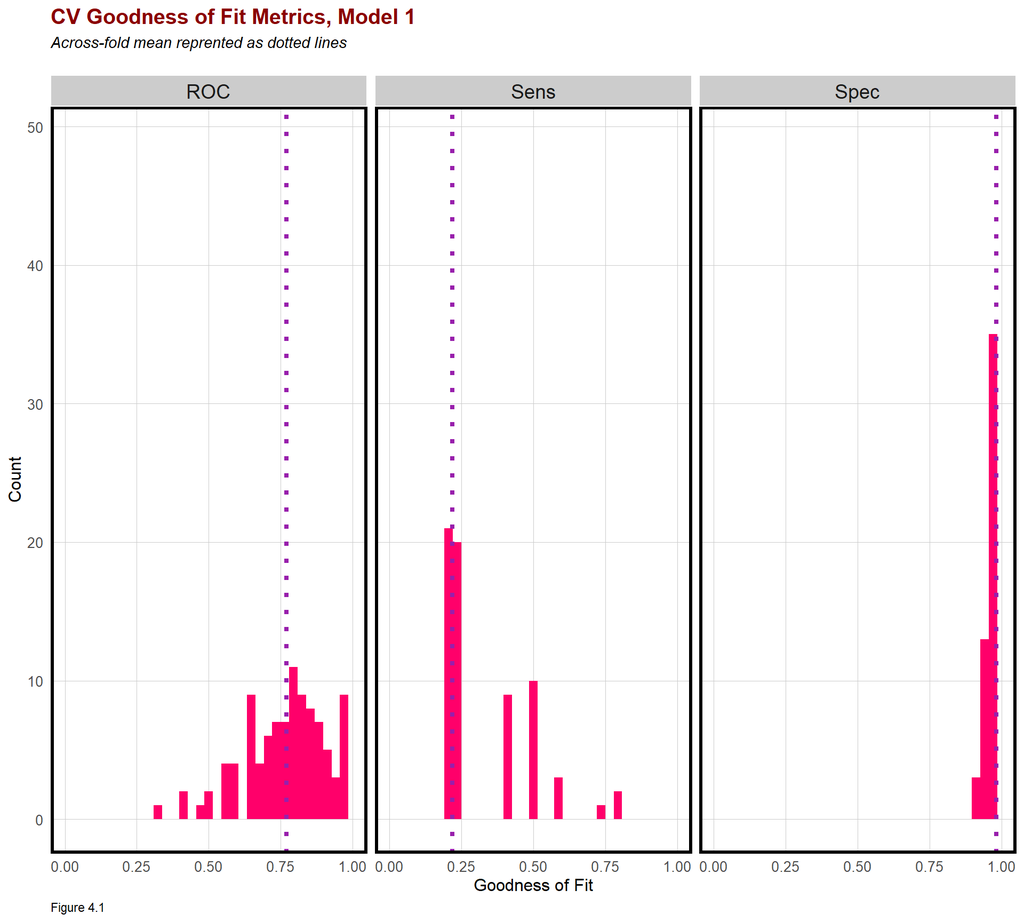

```r
dplyr::select(cvFit.reg1$resample, -Resample) %>%
  gather(metric, value) %>%
  left_join(gather(cvFit.reg1$results[2:4], metric, mean)) %>%
  ggplot(aes(value)) +
    geom_histogram(bins=35, fill = "#FF006A") +
    facet_wrap(~metric) +
    geom_vline(aes(xintercept = mean), colour = "#981FAC", linetype = 3, size = 1.5) +
    scale_x_continuous(limits = c(0, 1)) +
    labs(x="Goodness of Fit", y="Count",
         title="CV Goodness of Fit Metrics, Model 1",
         subtitle = "Across-fold mean reprented as dotted lines\n",
         caption = "Figure 4.1") +
  plotTheme()
```

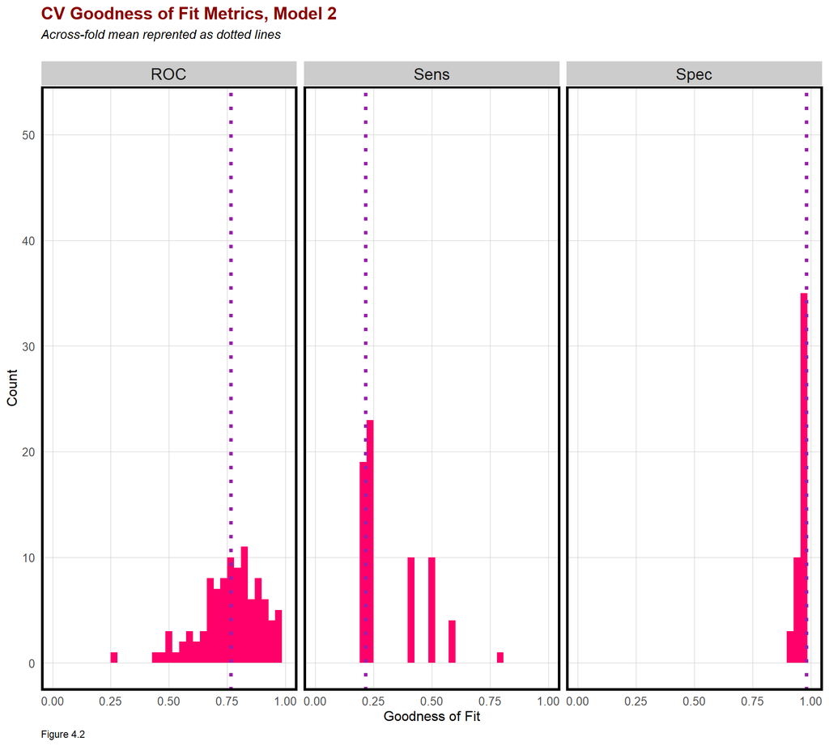

```r
dplyr::select(cvFit.reg2$resample, -Resample) %>%
  gather(metric, value) %>%
  left_join(gather(cvFit.reg2$results[2:4], metric, mean)) %>%
  ggplot(aes(value)) +
    geom_histogram(bins=35, fill = "#FF006A") +
    facet_wrap(~metric) +
    geom_vline(aes(xintercept = mean), colour = "#981FAC", linetype = 3, size = 1.5) +
    scale_x_continuous(limits = c(0, 1)) +
    labs(x="Goodness of Fit", y="Count",
         title="CV Goodness of Fit Metrics, Model 2",
         subtitle = "Across-fold mean reprented as dotted lines\n",
         caption = "Figure 4.2") +
    plotTheme()
```

## V. ROC Curve for New Model

According to the ROC Curve, a threshold that predicts credit acceptance correctly 80% of the time, will predict credit acceptance incorrectly >20% of the time. For every additional improvement in true positive rate, the model will make a greater proportion of false positive errors. Moving from a 85% to a 95% true positive rate dramatically increases the false positive rate.

```r
auc(testProbs2$Outcome2, testProbs2$Probs2)
```

```
## Area under the curve: 0.8015
```

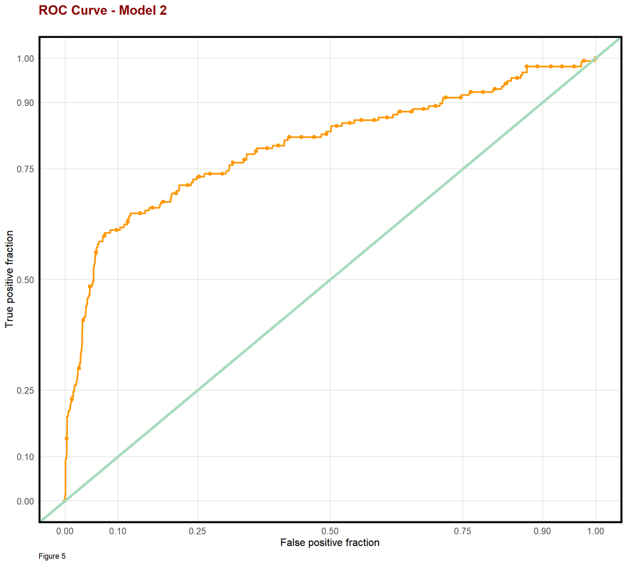

```r
ggplot(testProbs2, aes(d = as.numeric(testProbs2$Outcome2), m = Probs2)) +
  geom_roc(n.cuts = 50, labels = FALSE, colour = "#FE9900") +
  style_roc(theme = theme_grey) +
  geom_abline(slope = 1, intercept = 0, size = 1.5, color = '#a6dbbc') +
  labs(title = "ROC Curve - Model 2\n",
       caption = 'Figure 5') +
  plotTheme()
```

## VI. Cost-Benefit Analysis

This has all been building to an examination of the model in the context of our credit campaign. Let’s set this up to estimate the revenues associated with using this model under the following scenario:

### 6.1 Cost/Benefit Equation

- True Positive - Predicted correctly homeowner would take the credit; allocated the marketing resources, and 25% took the credit: `-$5000 - $2850 + ($10,000 + $56,000) * 0.08` return for 25% of cases that take credit, but only `$2850` lose for 75% of cases receive the marketing allocation but do not take the credit.
- True Negative - Predicted correctly homeowner would not take the credit, no marketing resources were allocated, and no credit was allocated: `$0`.
- False Positive - Predicted incorrectly homeowner would take the credit; allocated marketing resources; no credit allocated: `- $2850`
- False Negative - We predicted that a homeowner would not take the credit but they did. These are likely homeowners who signed up for reasons unrelated to the marketing campaign. Thus, we ‘0 out’ this category, assuming the cost/benefit of this is $0.

### 6.2 Create the “Cost/Benefit Table”

The table below presents the count and the revenue of the four categories under the default threshold of 0.5. Optimizing the threshold might generate a higher overall revenue.

```r
cost_benefit_table <-
   testProbs2 %>%
      count(predOutcome2, Outcome2) %>%
      summarize(True_Negative = sum(n[predOutcome2==0 & Outcome2==0]),
                True_Positive = sum(n[predOutcome2==1 & Outcome2==1]),
                False_Negative = sum(n[predOutcome2==0 & Outcome2==1]),
                False_Positive = sum(n[predOutcome2==1 & Outcome2==0])) %>%
       gather(Variable, Count) %>%
       mutate(Revenue =
               ifelse(Variable == "True_Negative", 0 *Count,
               ifelse(Variable == "True_Positive",((-5000 - 2850 + (10000 + 56000) * 0.08) * Count * 0.25 +
                                                    (- 2850) * Count * 0.75),
               ifelse(Variable == "False_Negative", 0 * Count,
               ifelse(Variable == "False_Positive", (- 2850) * Count, 0))))) %>%
    bind_cols(data.frame(Description = c(
              "Predicted correctly homeowner would not take the credit",
              "Predicted correctly homeowner would take the credit",
              "Predicted incorrectly homeowner would not take the credit",
              "Predicted incorrectly homeowner would take the credit")))


kable(cost_benefit_table) %>%
  kable_styling(font_size = 12, full_width = F,
                bootstrap_options = c("striped", "hover", "condensed")) %>%
  footnote(general = "Table 6.2 Cost/Benefit Table\n",
           general_title= '\n')
```

| Variable | Count | Revenue | Description |
| --- | --- | --- | --- |
| True_Negative | 1272 | 0 | Predicted correctly homeowner would not take the credit |
| True_Positive | 33 | -91740 | Predicted correctly homeowner would take the credit |
| False_Negative | 124 | 0 | Predicted incorrectly homeowner would not take the credit |
| False_Positive | 11 | -31350 | Predicted incorrectly homeowner would take the credit |

Table 6.2 Cost/Benefit Table

### 6.3 Optimize Thresholds

This section selects optimal thresholds by plot the confusion metric outcomes for each threshold.

```r
whichThreshold_subsidy <- iterateThresholds(testProbs2)

whichThreshold_subsidy_revenue <-
whichThreshold_subsidy %>%
    group_by(Threshold) %>%
    summarize(Revenue = sum(Revenue))
```

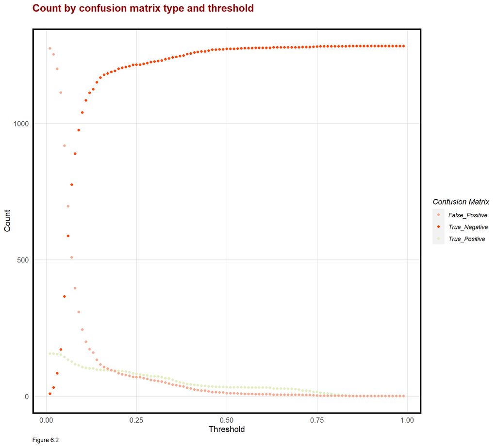

```r
whichThreshold_subsidy  %>%
  filter(Variable != 'False_Negative') %>%
  ggplot(.,aes(Threshold, Count, colour = Variable)) +
  geom_point() +
  scale_colour_manual(values = palette5[c(5, 1:3)]) +
  labs(title = "Count by confusion matrix type and threshold\n",
       y = "Count",
       caption = 'Figure 6.2') +
  plotTheme() +
  guides(colour=guide_legend(title = "Confusion Matrix"))
```

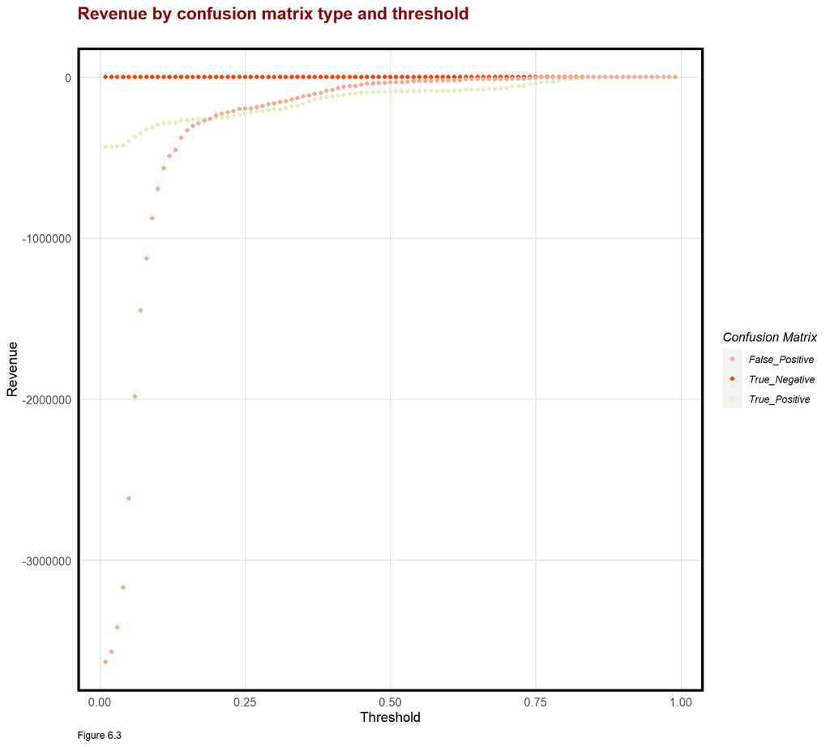

```r
whichThreshold_subsidy  %>%
  filter(Variable != 'False_Negative') %>%
  ggplot(.,aes(Threshold, Revenue, colour = Variable)) +
  geom_point() +
  scale_colour_manual(values = palette5[c(5, 1:3)]) +
  labs(title = "Revenue by confusion matrix type and threshold\n",
       y = "Revenue",
       caption = 'Figure 6.3') +
  plotTheme() +
  guides(colour=guide_legend(title = "Confusion Matrix"))
```

### 6.4 Threshold as a Function of Total Revenue and Total Count

```r
whichThreshold_subsidy_revenue <-
  whichThreshold_subsidy %>%
    mutate(total_count =
               ifelse(Variable == "True_Positive", Count * 0.25,
               ifelse(Variable == 'False_Negative', Count ,0 ))) %>%
    group_by(Threshold) %>%
    summarize(Total_Revenue = sum(Revenue),
              Total_Count_of_Credits = sum(total_count))
```

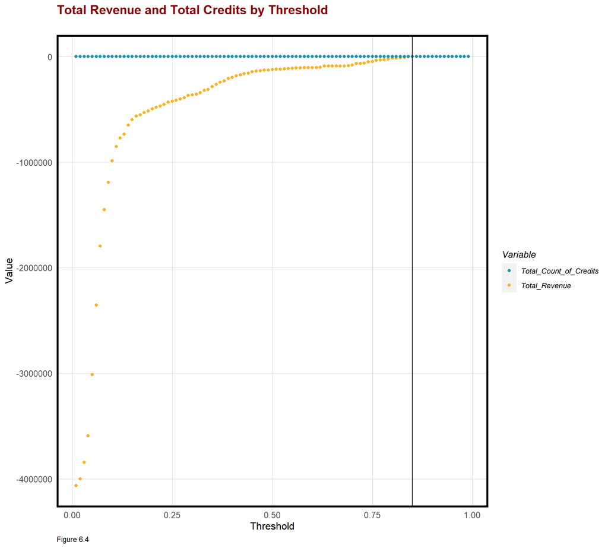

```r
whichThreshold_subsidy_revenue %>%
  dplyr::select(Threshold, Total_Revenue, Total_Count_of_Credits) %>%
  gather(Variable, Value, -Threshold) %>%
  ggplot(aes(Threshold, Value, colour = Variable)) +
    geom_point() +
    geom_vline(xintercept = pull(arrange(whichThreshold_subsidy_revenue, -Total_Revenue)[1,1])) +
    scale_y_continuous( limits=c(-4064571, 2000) )+
    scale_colour_manual(values = palette2) +

    plotTheme() +
    labs(title = "Total Revenue and Total Credits by Threshold\n",
         caption = 'Figure 6.4')
```

### 6.5 Table of Total Revenue and Total Count

Optimizing the threshold turned the revenue from negative to positive and increased the count of credit acceptance.

```r
output_table <- rbind(whichThreshold_subsidy_revenue[50,],whichThreshold_subsidy_revenue[85,])


kable(output_table) %>%
  kable_styling(font_size = 12, full_width = F,
                bootstrap_options = c("striped", "hover", "condensed")) %>%
  footnote(general = "Table 6.5 Total Revenue and Credit by Threshold\n",
           general_title= '\n')
```

| Threshold | Total_Revenue | Total_Count_of_Credits |
| --- | --- | --- |
| 0.50 | -121818 | 132.25 |
| 0.85 | 1283 | 157.00 |

Table 6.5 Total Revenue and Credit by Threshold